# Regional Phase Model Summary

# Uniform Phase Models

## Model 0 Results

### MCMC Diagnostics

- Number of parameters with Rhat below 1.01:4
- Of which $\theta$ parameters were :4
- Smallest Effective Samples Size: 492.1611325
- Smallest Effective Sample Size without $\theta$ parameters: 1.3533484^{4}

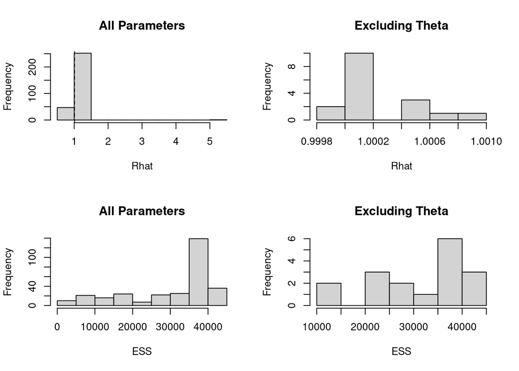

### Agreement Index

- Overall agreement Index: 53.15
- Percentage individual agreement index < 60%: 2.12

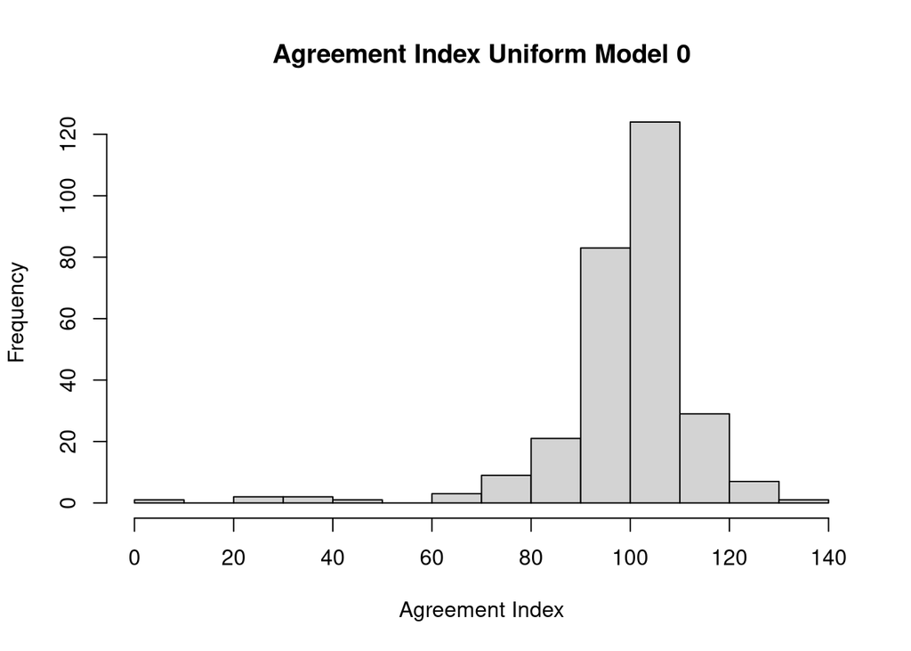

### Posterior Estimates

Marginal posterior distribution of start dates:

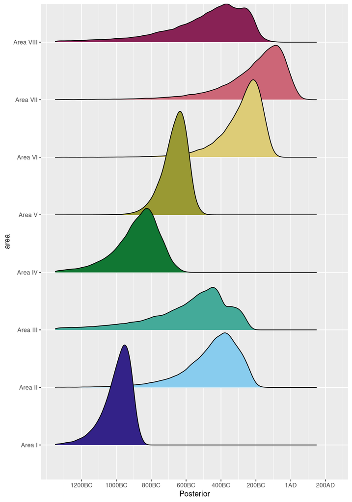

Marginal posterior summary statistics:

| Area | 95%(lo) | 50%(lo) | Median | 50%(hi) | 95%(hi) |
| --- | --- | --- | --- | --- | --- |
| Area I | BC 1172 | BC 1002 | BC 980 | BC 910 | BC 863 |
| Area II | BC 792 | BC 476 | BC 423 | BC 302 | BC 207 |
| Area III | BC 1323 | BC 644 | BC 542 | BC 381 | BC 227 |
| Area IV | BC 1183 | BC 921 | BC 864 | BC 771 | BC 650 |
| Area V | BC 818 | BC 683 | BC 655 | BC 596 | BC 542 |
| Area VI | BC 539 | BC 287 | BC 255 | BC 165 | BC 99 |
| Area VII | BC 628 | BC 205 | BC 166 | BC 29 | AD 49 |
| Area VIII | BC 1100 | BC 482 | BC 442 | BC 230 | BC 134 |

Probability temporal order (probability row being earlier than column):

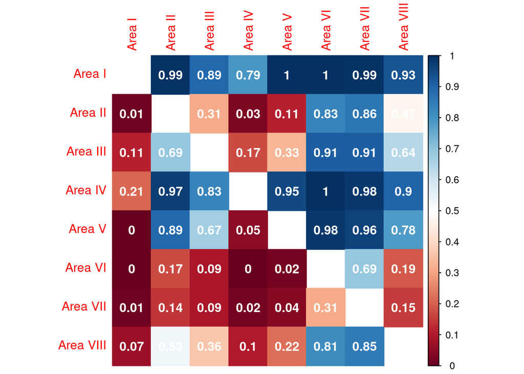

## Model 1 Results

### MCMC Diagnostics

- Number of parameters with Rhat below 1.01:2
- Of which $\theta$ parameters were :2
- Smallest Effective Samples Size: 639.5751602
- Smallest Effective Sample Size without $\theta$ parameters: 1.1197622^{4}

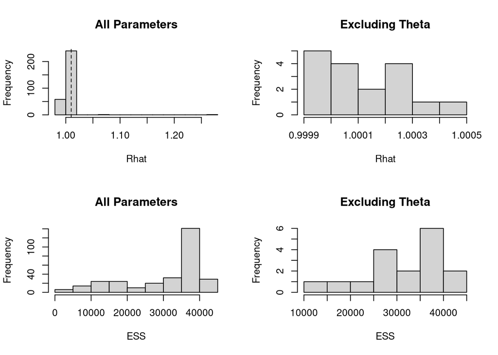

### Agreement Index

- Overall agreement Index: 73.57
- Percentage individual agreement index < 60%: 1.77

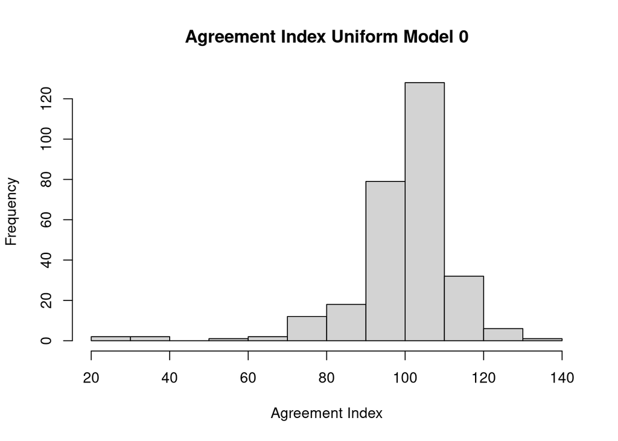

### Posterior Estimates

Marginal posterior distribution of start dates:

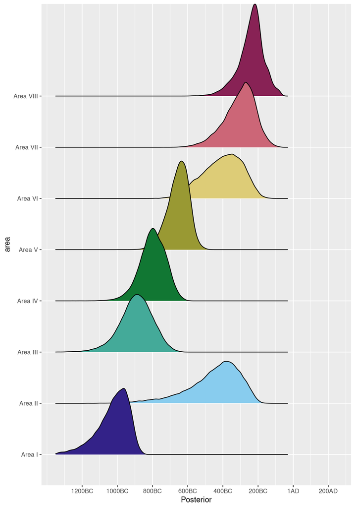

Marginal posterior summary statistics:

| Area | 95%(lo) | 50%(lo) | Median | 50%(hi) | 95%(hi) |
| --- | --- | --- | --- | --- | --- |
| Area I | BC 1225 | BC 1033 | BC 1008 | BC 927 | BC 878 |
| Area II | BC 759 | BC 468 | BC 422 | BC 297 | BC 206 |
| Area III | BC 1083 | BC 945 | BC 889 | BC 824 | BC 710 |
| Area IV | BC 943 | BC 838 | BC 796 | BC 742 | BC 657 |
| Area V | BC 778 | BC 678 | BC 648 | BC 600 | BC 546 |
| Area VI | BC 615 | BC 440 | BC 393 | BC 285 | BC 206 |
| Area VII | BC 491 | BC 330 | BC 293 | BC 219 | BC 143 |
| Area VIII | BC 393 | BC 266 | BC 231 | BC 187 | BC 101 |

Probability temporal order (probability row being earlier than column):

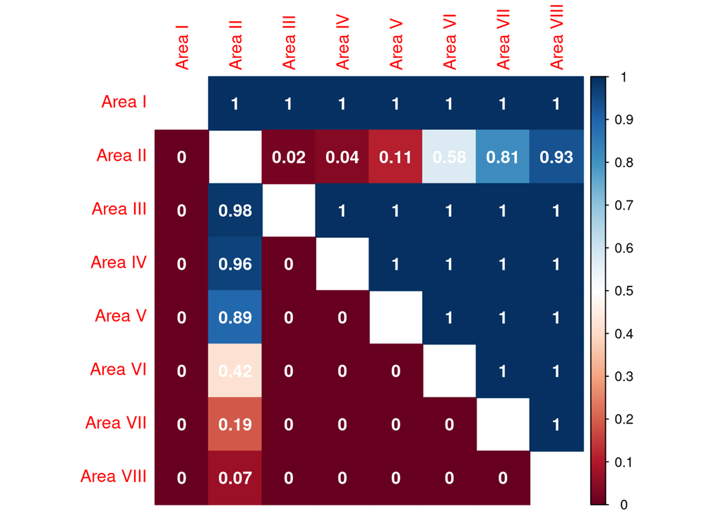

## Model 2 Results

### MCMC Diagnostics

- Number of parameters with Rhat below 1.01:5
- Of which $\theta$ parameters were :5
- Smallest Effective Samples Size: 612.1200332
- Smallest Effective Sample Size without $\theta$ parameters: 1.0469194^{4}

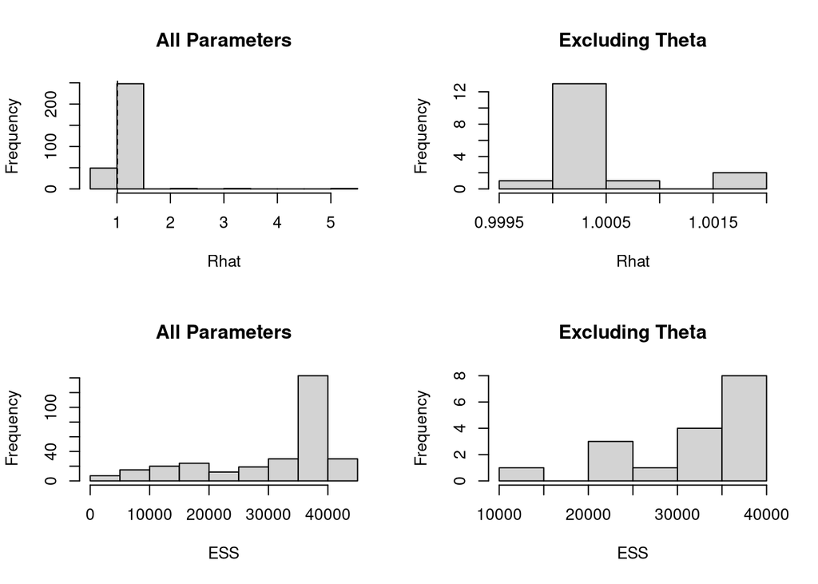

### Agreement Index

- Overall agreement Index: 58.27
- Percentage individual agreement index < 60%: 2.47

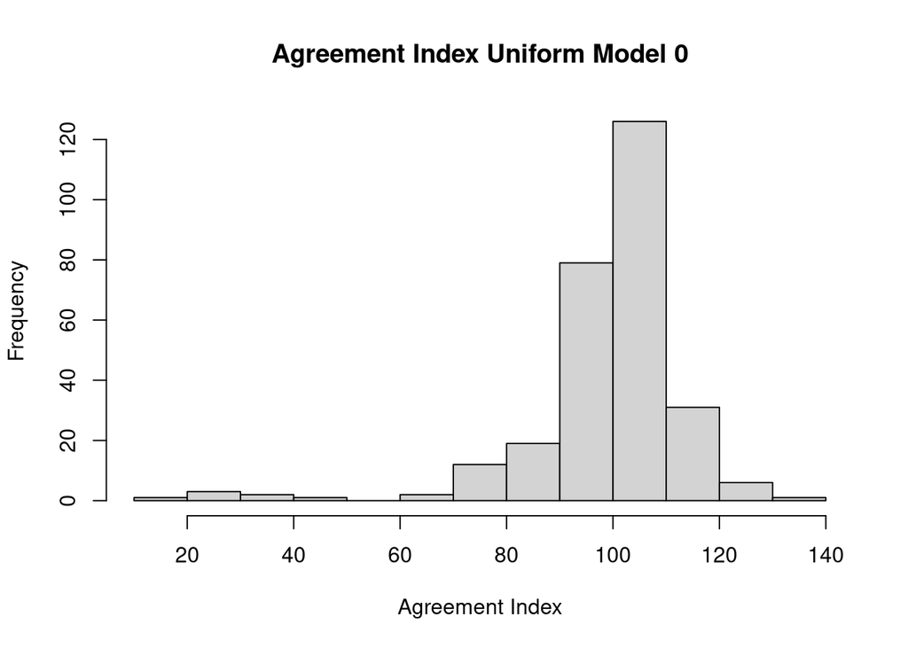

### Posterior Estimates

Marginal posterior distribution of start dates:

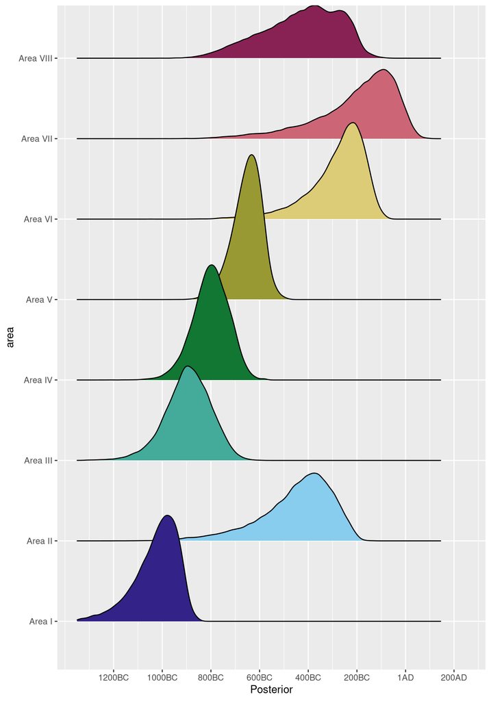

Marginal posterior summary statistics:

| Area | 95%(lo) | 50%(lo) | Median | 50%(hi) | 95%(hi) |
| --- | --- | --- | --- | --- | --- |
| Area I | BC 1225 | BC 1036 | BC 1009 | BC 930 | BC 879 |
| Area II | BC 760 | BC 472 | BC 421 | BC 302 | BC 207 |
| Area III | BC 1081 | BC 950 | BC 891 | BC 829 | BC 710 |
| Area IV | BC 944 | BC 842 | BC 798 | BC 745 | BC 655 |
| Area V | BC 776 | BC 675 | BC 646 | BC 600 | BC 545 |
| Area VI | BC 531 | BC 284 | BC 255 | BC 164 | BC 103 |
| Area VII | BC 545 | BC 199 | BC 162 | BC 30 | AD 46 |
| Area VIII | BC 743 | BC 456 | BC 408 | BC 241 | BC 176 |

Probability temporal order (probability row being earlier than column):

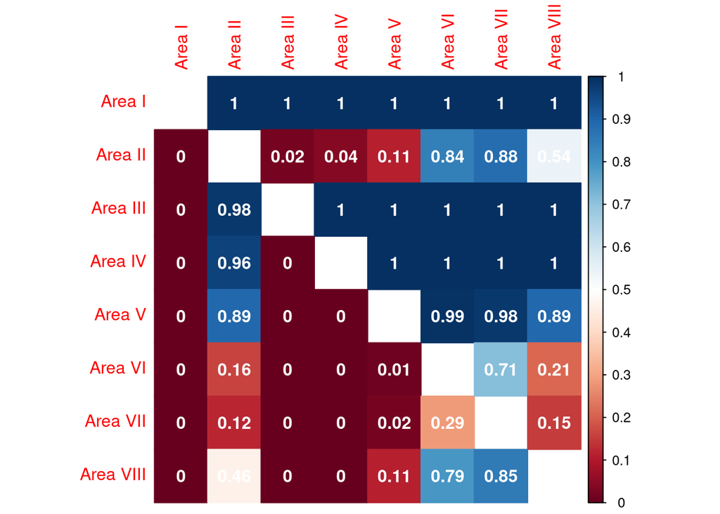

# Trapezium Models

## Model 0 Results

### MCMC Diagnostics

- Number of parameters with Rhat below 1.01:4
- Of which $\theta$ parameters were :4
- Smallest Effective Samples Size: 410.4592393
- Smallest Effective Sample Size without $\theta$ parameters: 2.5557728^{4}

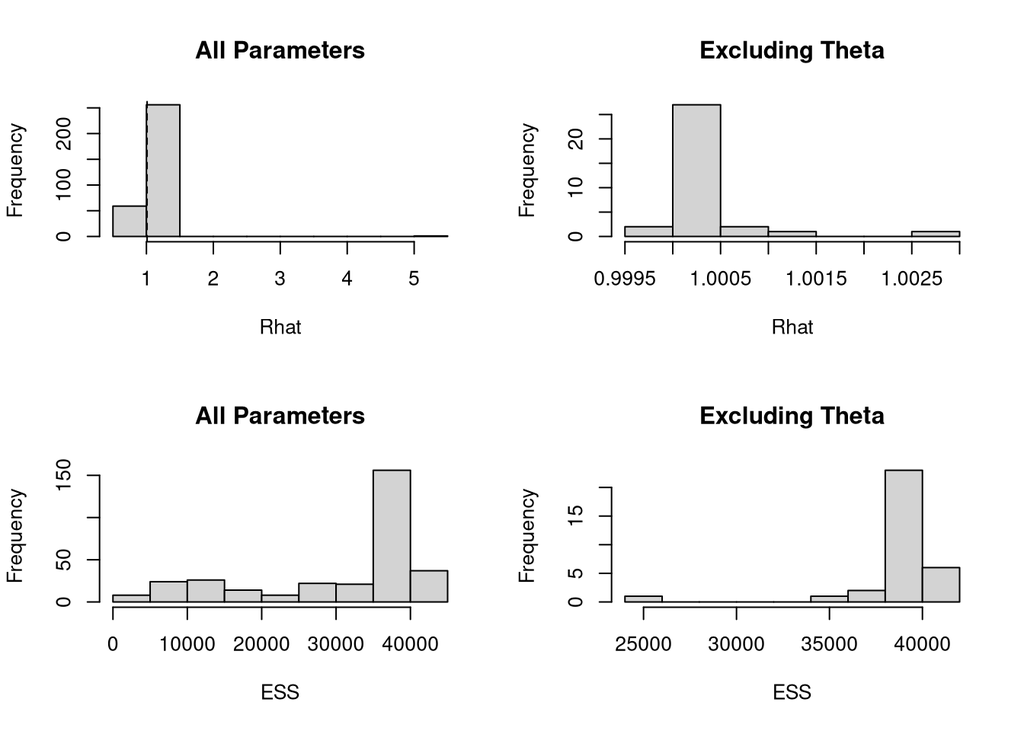

### Agreement Index

- Overall agreement Index: 59.1
- Percentage individual agreement index < 60%: 2.12

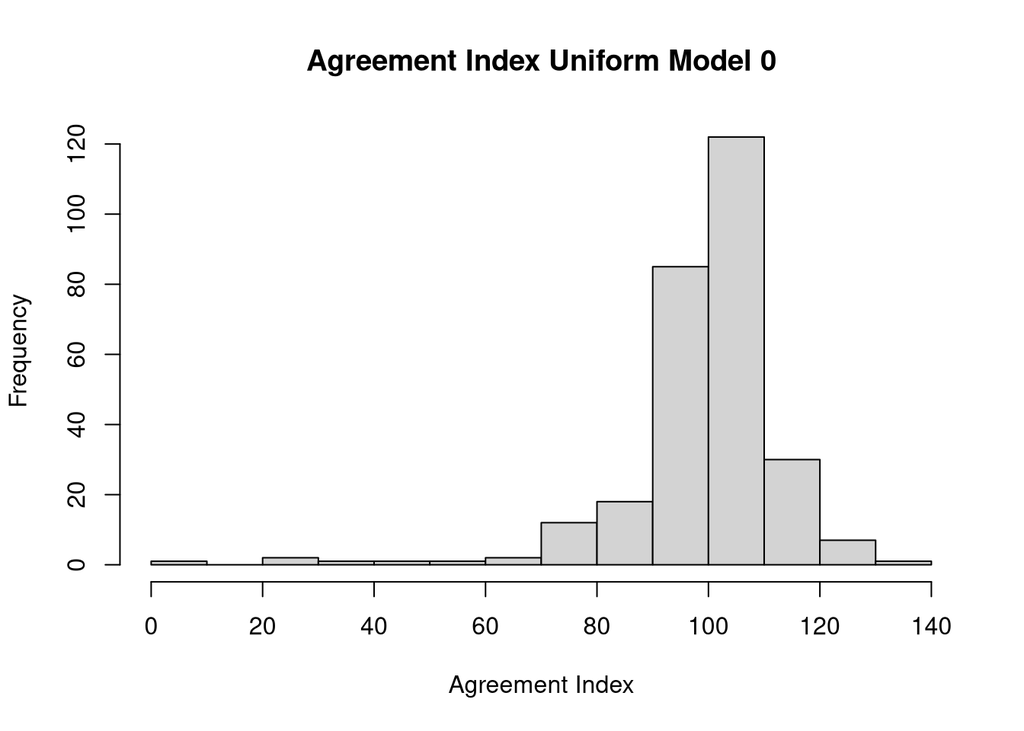

### Posterior Estimates

Marginal posterior distribution of start dates:

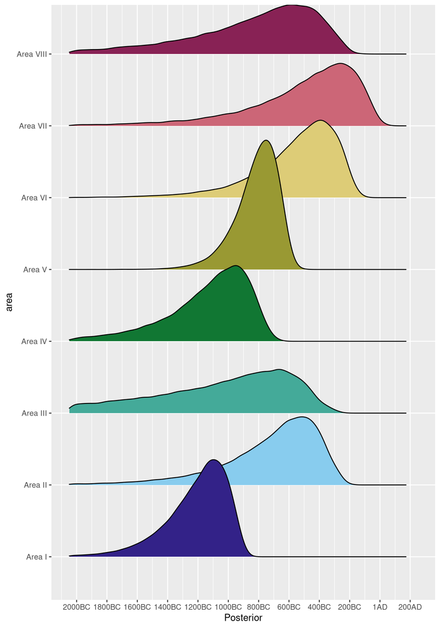

Marginal posterior summary statistics:

| Area | 95%(lo) | 50%(lo) | Median | 50%(hi) | 95%(hi) |
| --- | --- | --- | --- | --- | --- |
| Area I | BC 1640 | BC 1217 | BC 1169 | BC 988 | BC 906 |
| Area II | BC 1426 | BC 725 | BC 648 | BC 393 | BC 250 |
| Area III | BC 2505 | BC 1092 | BC 1019 | BC 472 | BC 321 |
| Area IV | BC 1811 | BC 1150 | BC 1083 | BC 843 | BC 708 |
| Area V | BC 1099 | BC 839 | BC 792 | BC 673 | BC 580 |
| Area VI | BC 1137 | BC 559 | BC 497 | BC 269 | BC 150 |
| Area VII | BC 1352 | BC 485 | BC 427 | BC 115 | BC 4 |
| Area VIII | BC 1945 | BC 857 | BC 762 | BC 374 | BC 202 |

Probability temporal order (probability row being earlier than column):

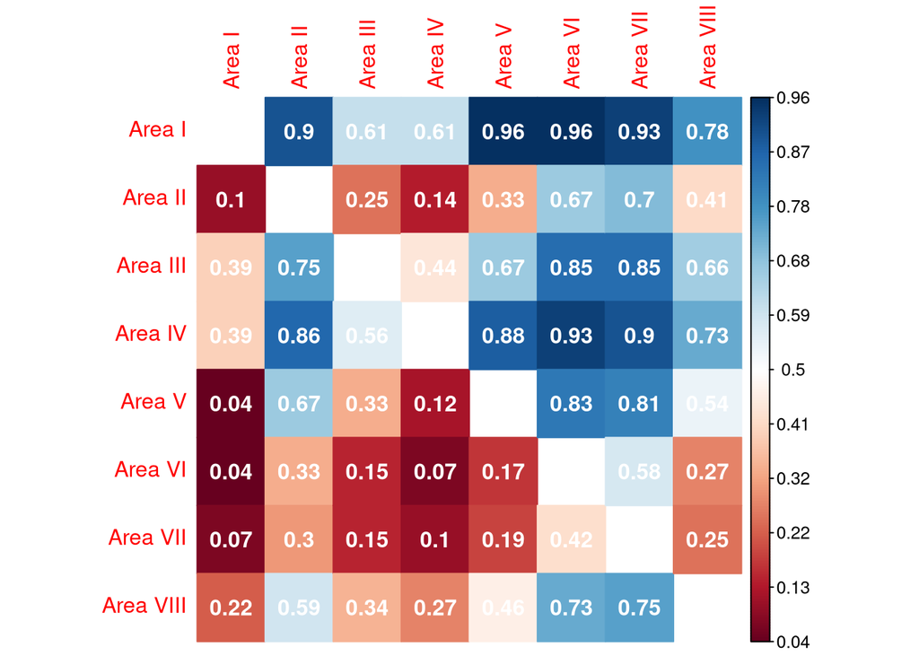

## Model 1 Results

### MCMC Diagnostics

- Number of parameters with Rhat below 1.01:5
- Of which $\theta$ parameters were :5
- Smallest Effective Samples Size: 515.4893087
- Smallest Effective Sample Size without $\theta$ parameters: 2.6365743^{4}

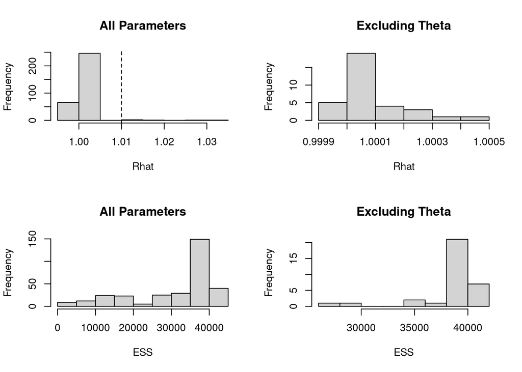

### Agreement Index

- Overall agreement Index: 76.18
- Percentage individual agreement index < 60%: 1.77

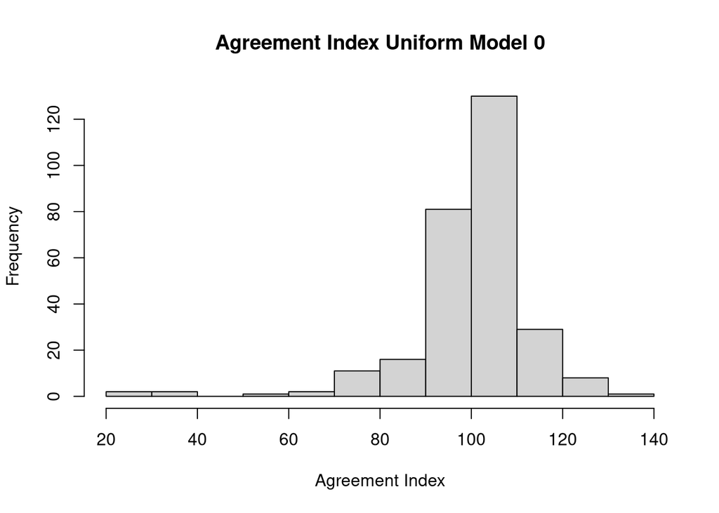

### Posterior Estimates

Marginal posterior distribution of start dates:

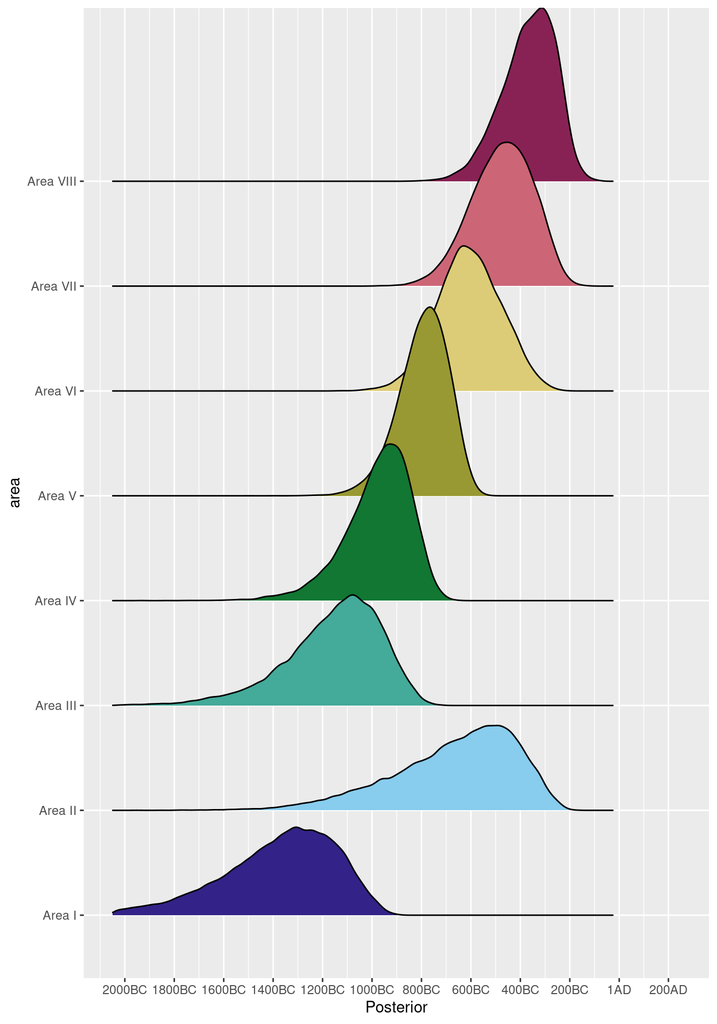

Marginal posterior summary statistics:

| Area | 95%(lo) | 50%(lo) | Median | 50%(hi) | 95%(hi) |
| --- | --- | --- | --- | --- | --- |
| Area I | BC 1887 | BC 1430 | BC 1348 | BC 1131 | BC 964 |
| Area II | BC 1176 | BC 701 | BC 624 | BC 396 | BC 273 |
| Area III | BC 1564 | BC 1203 | BC 1128 | BC 966 | BC 822 |
| Area IV | BC 1250 | BC 1011 | BC 958 | BC 850 | BC 745 |
| Area V | BC 989 | BC 840 | BC 784 | BC 707 | BC 604 |
| Area VI | BC 859 | BC 704 | BC 609 | BC 529 | BC 356 |
| Area VII | BC 711 | BC 544 | BC 468 | BC 370 | BC 240 |
| Area VIII | BC 595 | BC 400 | BC 355 | BC 257 | BC 189 |

Probability temporal order (probability row being earlier than column):

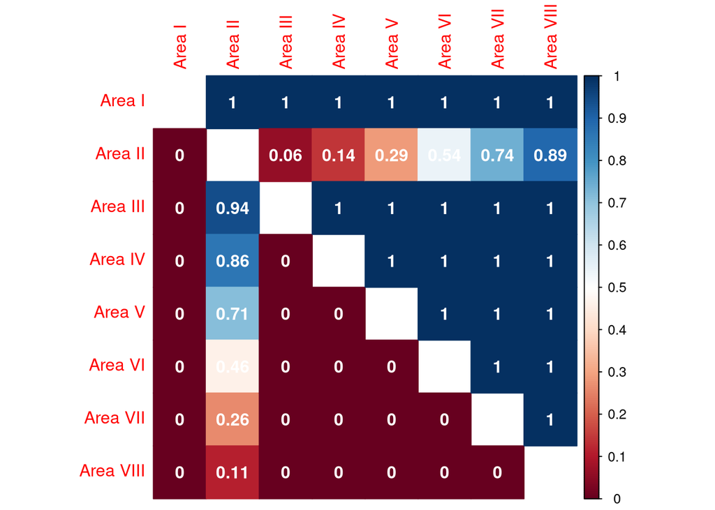

## Model 2 Results

### MCMC Diagnostics

- Number of parameters with Rhat below 1.01:7
- Of which $\theta$ parameters were :7
- Smallest Effective Samples Size: 467.9612092
- Smallest Effective Sample Size without $\theta$ parameters: 2.7331912^{4}

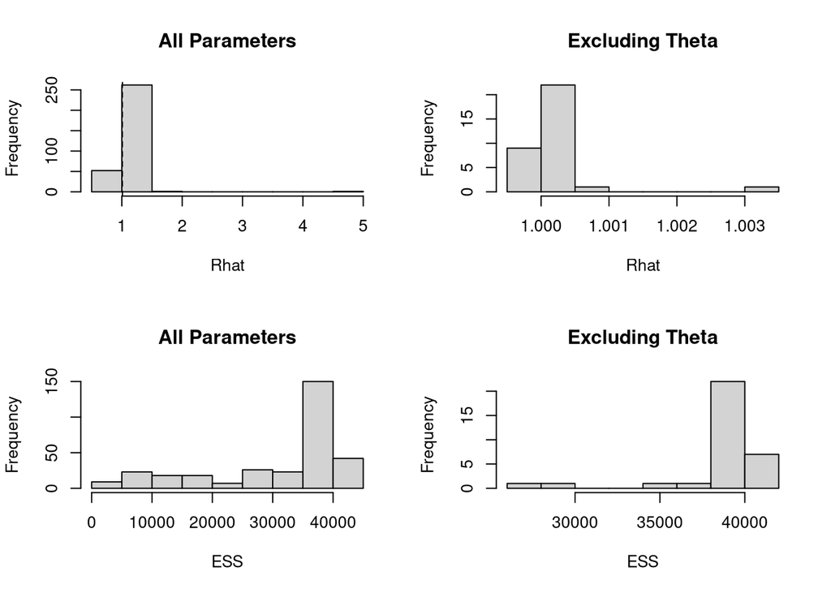

### Agreement Index

- Overall agreement Index: 73.52
- Percentage individual agreement index < 60%: 1.77

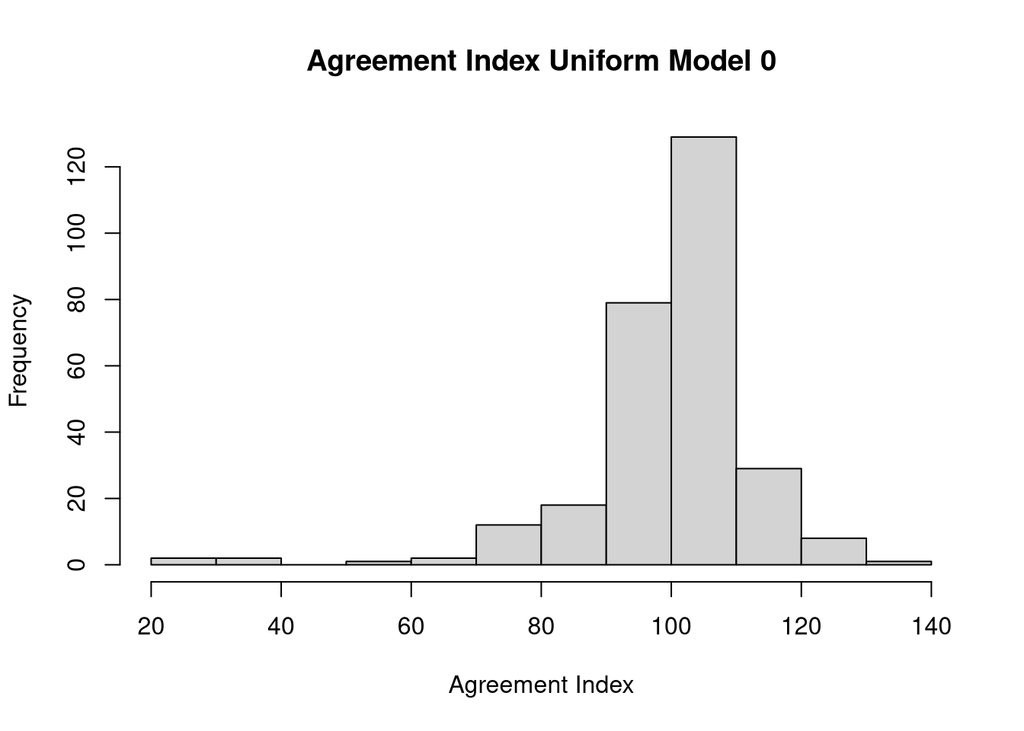

### Posterior Estimates

Marginal posterior distribution of start dates:

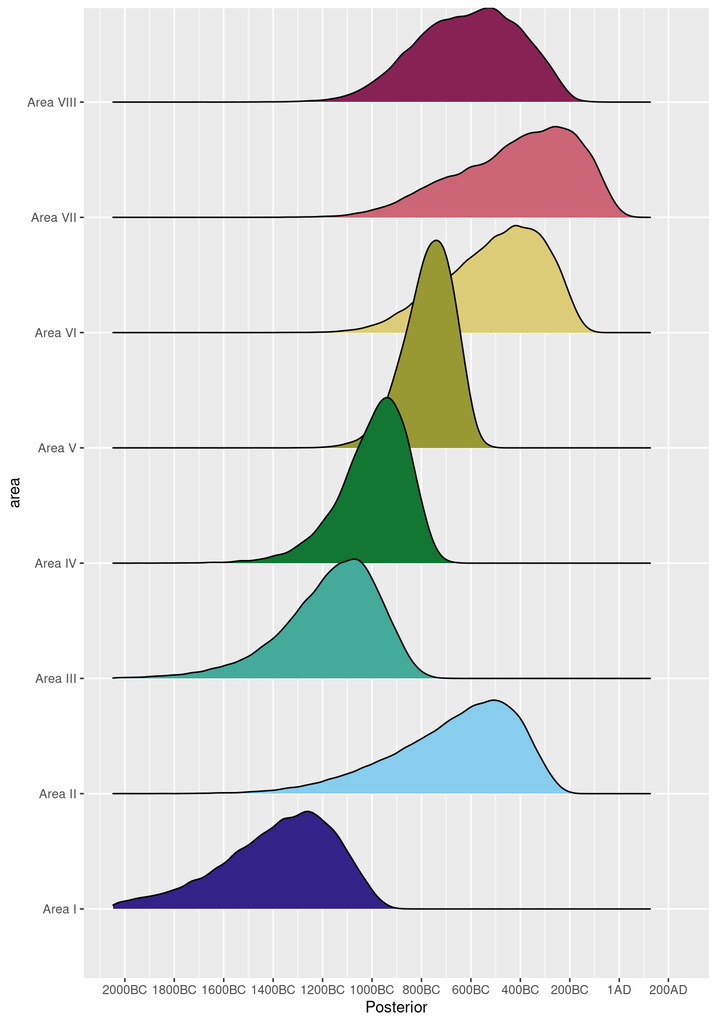

Marginal posterior summary statistics:

| Area | 95%(lo) | 50%(lo) | Median | 50%(hi) | 95%(hi) |
| --- | --- | --- | --- | --- | --- |
| Area I | BC 1912 | BC 1446 | BC 1357 | BC 1143 | BC 981 |
| Area II | BC 1179 | BC 699 | BC 625 | BC 393 | BC 269 |
| Area III | BC 1587 | BC 1220 | BC 1143 | BC 982 | BC 835 |
| Area IV | BC 1276 | BC 1030 | BC 975 | BC 859 | BC 747 |
| Area V | BC 974 | BC 809 | BC 761 | BC 677 | BC 591 |
| Area VI | BC 889 | BC 539 | BC 476 | BC 276 | BC 178 |
| Area VII | BC 884 | BC 458 | BC 378 | BC 146 | BC 35 |
| Area VIII | BC 995 | BC 727 | BC 600 | BC 428 | BC 239 |

Probability temporal order (probability row being earlier than column):

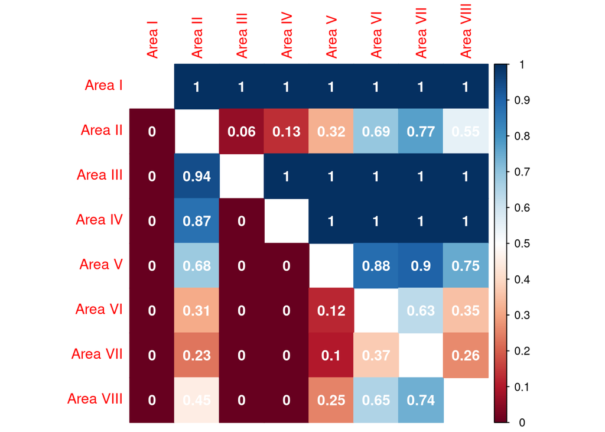